# A Review of R, Cytoscape and Python Integration for Data Visualization and Exploration

[`R`](http://cran.r-project.org/) is a popular data analysis and visualization environment, with a large number of user contributed packages, and the ability for interested individuals to easily contribute their own packages.

`Cytoscape` is a popular network visualization software.

`Python` is an alternative popular data analysis environment.

Metabolomics data and networks are courtesy of Dmitry Grapov's [Creative Data Solutions](http://imdevsoftware.wordpress.com/2014/02/17/tutorials-statistical-and-multivariate-analysis-for-metabolomics/) metabolomic tutorial.

## Why R, ggplot2

`R` is useful because of the various statistical utilities available. `R` has a set of base graphics utilities that allow one to do various types of plots. As a simple example, we can create a scatterplot of two variables:

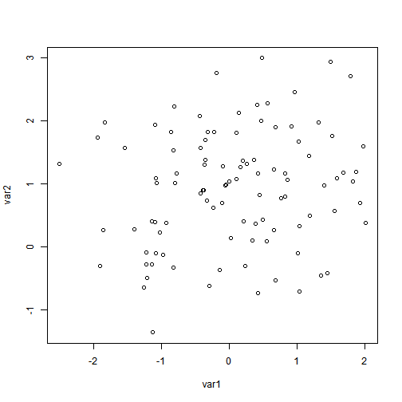

```r
var1 <- rnorm(100)
var2 <- rnorm(100, 1)
plot(var1, var2)
```

Or do a histogram of one of the variables:

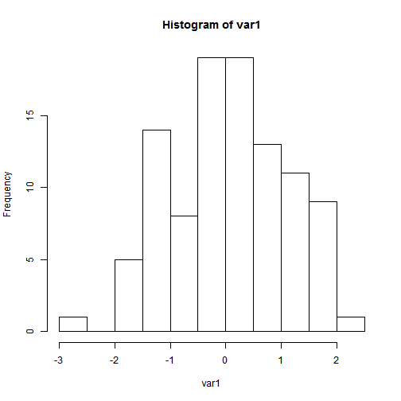

```r
hist(var1)
```

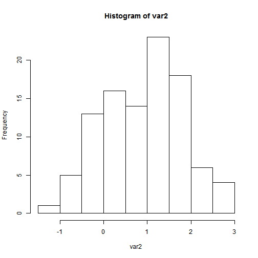

```r
hist(var2)
```

But doing much else in base graphics can get rather tedious and difficult, especially when you want multiple plots.

As a simple example, lets imagine that we have two replicates of each variable that we want to examine.

```r
varData <- data.frame(var1 = c(rnorm(100), rnorm(100)), var2 = c(rnorm(100,
    1), rnorm(100, 1)), sample = rep(c(1, 2), each = 100))
```

Using base graphics, we can easily plot the two variables against each other:

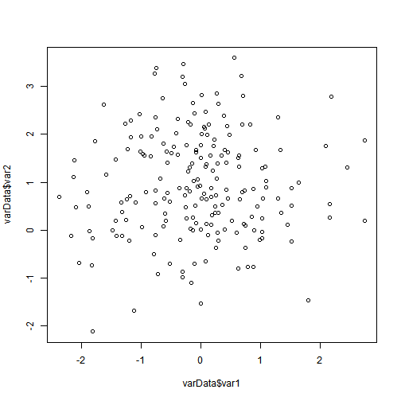

```r
plot(varData$var1, varData$var2)
```

But if we want to do it by sample, things quickly get more complicated:

[figure not shown]

```r
plot(varData$var1[varData$sample == 1], varData$var2[varData$sample == 1], col = "blue")
points(varData$var1[varData$sample == 2], varData$var2[varData$sample == 2],
    col = "red")
```

We are no longer using the base `plot` command, but a sub-part of it. And plumbing it's depths quickly becomes tedious.

## GGPlot2

Enter [`ggplot2`](http://ggplot2.org/). It is an `R` implementation of the [*grammar of graphics*](http://www.amazon.com/Grammar-Graphics-Statistics-Computing/dp/0387245448). To better understand it's design and how it treats entries and variables, I recommend reading Hadley Wickham's [Tidy Data](http://vita.had.co.nz/papers/tidy-data.pdf) manuscript.

Using `ggplot2`, our previous graph becomes rather trivial.

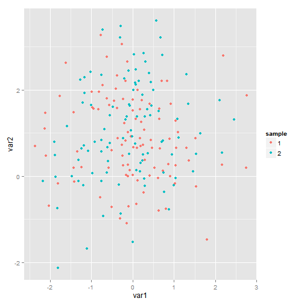

```r
library(ggplot2)
varData$sample <- factor(varData$sample)
ggplot(varData, aes(x = var1, y = var2, colour = sample)) + geom_point()
```

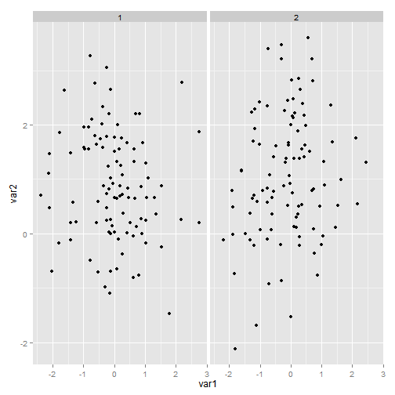

```r
ggplot(varData, aes(x = var1, y = var2)) + geom_point() + facet_grid(. ~ sample)
```

In it's current form, we can easily plot summary histograms of each variable:

```
## stat_bin: binwidth defaulted to range/30. Use 'binwidth = x' to adjust this.
```

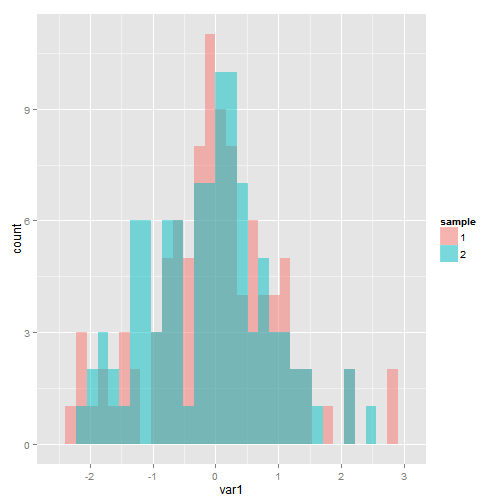

```r
ggplot(varData, aes(x = var1, fill = sample)) + geom_bar(position = "identity",
    alpha = 0.5)
```

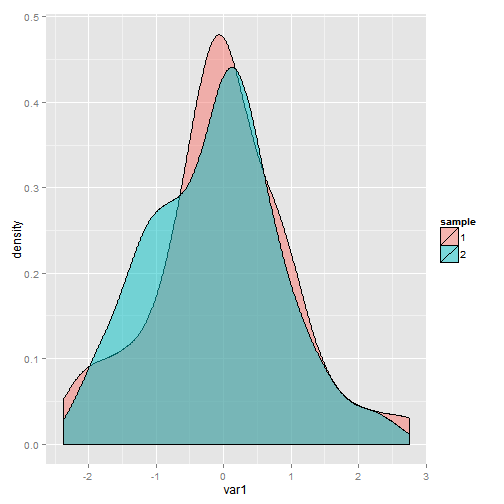

```r
ggplot(varData, aes(x = var1, fill = sample)) + geom_density(alpha = 0.5)
```

```
## stat_bin: binwidth defaulted to range/30. Use 'binwidth = x' to adjust this.
## stat_bin: binwidth defaulted to range/30. Use 'binwidth = x' to adjust this.
```

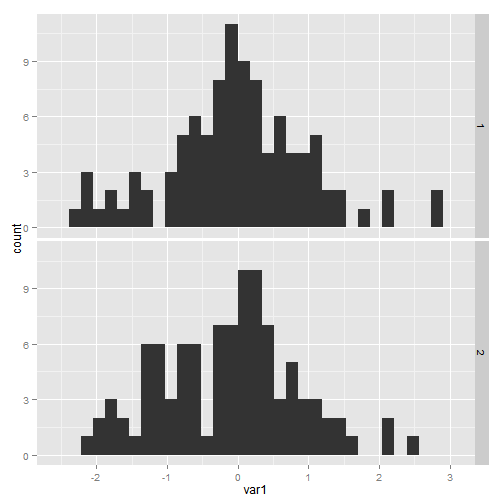

```r
ggplot(varData, aes(x = var1)) + geom_bar() + facet_grid(sample ~ .)
```

If we want to do a bigger overview of summary statistics, we can just reshape our data a little bit:

```
## stat_bin: binwidth defaulted to range/30. Use 'binwidth = x' to adjust this.
## stat_bin: binwidth defaulted to range/30. Use 'binwidth = x' to adjust this.
```

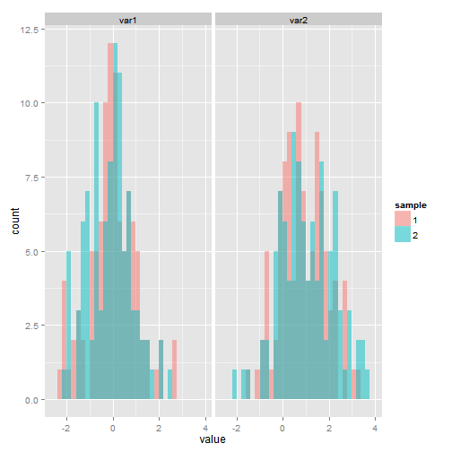

```r
library(reshape2)
varData2 <- melt(varData, measure.vars = c("var1", "var2"))

ggplot(varData2, aes(x = value, fill = sample)) + geom_bar(position = "identity",
    alpha = 0.5) + facet_grid(. ~ variable)
```

```
## stat_bin: binwidth defaulted to range/30. Use 'binwidth = x' to adjust this.
## stat_bin: binwidth defaulted to range/30. Use 'binwidth = x' to adjust this.
## stat_bin: binwidth defaulted to range/30. Use 'binwidth = x' to adjust this.
## stat_bin: binwidth defaulted to range/30. Use 'binwidth = x' to adjust this.
```

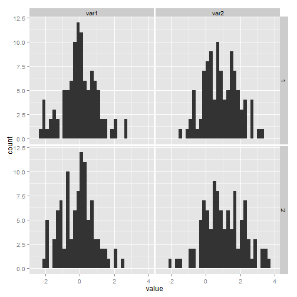

```r
ggplot(varData2, aes(x = value)) + geom_bar() + facet_grid(sample ~ variable)
```

## With Metabolomics Data

```r
metabData <- read.table("pumpkin_tomatillo_data.csv", sep = ",", header = T,
    stringsAsFactors = FALSE)
colnames(metabData)[4:151] <- seq(1, 148)

metab2 <- melt(metabData, id.vars = seq(1, 3), measure.vars = seq(4, 151))
varNameData <- read.table("metabID.csv", sep = ",", header = T, stringsAsFactors = FALSE)

metab2$metabName <- rep(varNameData$name, each = 24)
metabData <- metab2
newTreat <- rep("fresh", nrow(metabData))
newTreat[grep("lyophilized", metabData$Treatment)] <- "lyoph"
metabData$treat <- newTreat
```

Let's summarize the values for each type of sample.

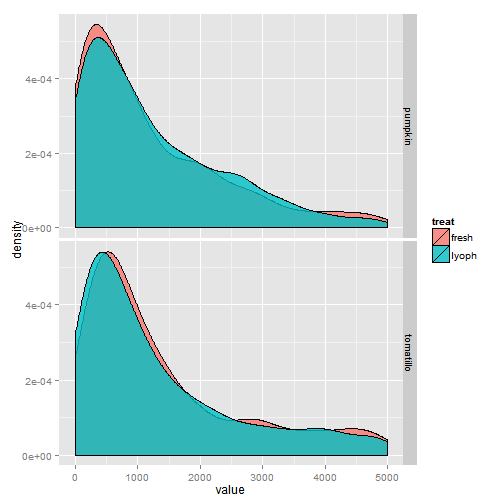

```r
ggplot(metabData, aes(x = value, fill = treat)) + geom_density(alpha = 0.8) +
    facet_grid(Species ~ ., scales = "free_y") + xlim(0, 5000)
```

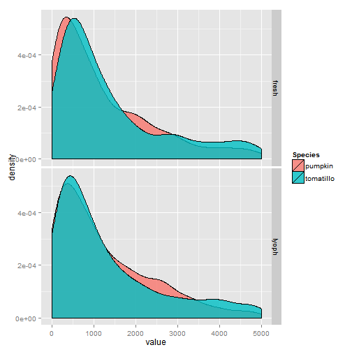

```r
ggplot(metabData, aes(x = value, fill = Species)) + geom_density(alpha = 0.8) +
    facet_grid(treat ~ ., scales = "free_y") + xlim(0, 5000)
```

We can also do the boxplot for all the metabolites, with a separate box for each species.

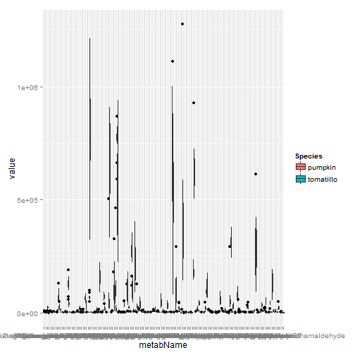

```r
ggplot(metabData, aes(x = metabName, y = value, fill = Species)) + geom_boxplot()
```

This is not that easily to decipher, but it was quite easy to do.

Based on the analysis presented in the tutorial, we can pick out some of the top changers:

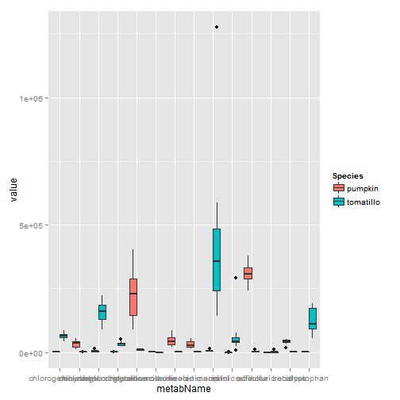

```r
topChangers <- c(34, 62, 8, 17, 124, 100, 115, 9, 93, 123, 75, 71, 85, 33)
metabTop <- metabData[(metabData$variable %in% topChangers), ]
ggplot(metabTop, aes(x = metabName, y = value, fill = Species)) + geom_boxplot()
```

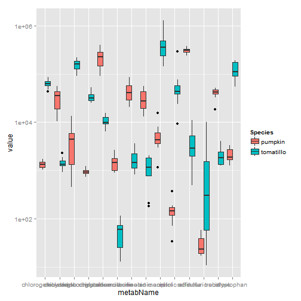

```r
ggplot(metabTop, aes(x = metabName, y = value, fill = Species)) + geom_boxplot() +
    scale_y_log10()
```

Finally, what is also quite nice about using `ggplot2` is the ability to add incrementally to a graph. In our previous example, we could have achieved the same result piecemeal like this:

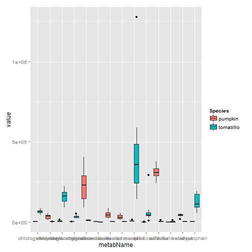

```r
g <- ggplot(metabTop, aes(x = metabName, y = value, fill = Species)) + geom_boxplot()
print(g)
```

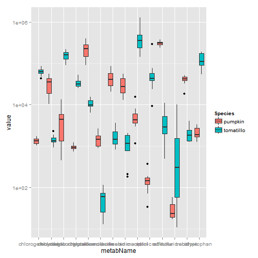

```r
g + scale_y_log10()
```

# Networks

Networks are very useful things in many fields, due to the fact that we can easily come up with ways to define relationships between objects. These objects can be anything, but in the context of metabolomics they are often `genes`, `proteins`, and `metabolites`. The relationships between metabolites can be defined in a couple of different ways. This example we will define edges between metabolites by links in the `KEGG` database, and by their chemical similarity (tanimoto coefficient). All data was generated by `metamapR`.

The network graph will be constructed in `R`, and visualized in `Cytoscape`. This gives us the flexibility to manipulate the graph easily in `R` and save groups of relevant nodes, with the visual flexibility of `Cytoscape`.

```r
library(graph)
nodeEdges <- read.table("biochemEdgeList.csv", header = T, sep = ",", stringsAsFactors = FALSE)

# need character for node IDs
nodeEdges[, 1] <- as.character(nodeEdges[, 1])
nodeEdges[, 2] <- as.character(nodeEdges[, 2])
```

```r
allNodes <- unique(c(nodeEdges$source, nodeEdges$target))

metabNetwork <- graphNEL(nodes = allNodes, edgemode = "directed")
metabNetwork <- addEdge(nodeEdges$source, nodeEdges$target, metabNetwork, nodeEdges$weight)
```

We also need the node and edge attributes, and to decide how they will be represented in the graph so that the types can be properly passed to Cytoscape.

```r
nodeData <- read.table("node_attributes.csv", header = T, sep = ",", stringsAsFactors = FALSE)
nodeData$Index <- as.character(nodeData$Index)

nodeDataDefaults(metabNetwork, "name") <- ""
attr(nodeDataDefaults(metabNetwork, "name"), "class") <- "STRING"
nodeDataDefaults(metabNetwork, "direction") <- ""
attr(nodeDataDefaults(metabNetwork, "direction"), "class") <- "STRING"
nodeDataDefaults(metabNetwork, "sig.dir") <- ""
attr(nodeDataDefaults(metabNetwork, "sig.dir"), "class") <- "STRING"
nodeDataDefaults(metabNetwork, "size.FC") <- 0
attr(nodeDataDefaults(metabNetwork, "size.FC"), "class") <- "DOUBLE"
nodeDataDefaults(metabNetwork, "size.log.FC") <- 0
attr(nodeDataDefaults(metabNetwork, "size.log.FC"), "class") <- "DOUBLE"
nodeDataDefaults(metabNetwork, "size.LV") <- 0
attr(nodeDataDefaults(metabNetwork, "size.LV"), "class") <- "DOUBLE"
nodeDataDefaults(metabNetwork, "log.mean.Pumpkin") <- 0
attr(nodeDataDefaults(metabNetwork, "log.mean.Pumpkin"), "class") <- "DOUBLE"
nodeDataDefaults(metabNetwork, "log.mean.Tomatillo") <- 0
attr(nodeDataDefaults(metabNetwork, "log.mean.Tomatillo"), "class") <- "DOUBLE"

edgeDataDefaults(metabNetwork, "weight") <- 0
attr(edgeDataDefaults(metabNetwork, "weight"), "class") <- "DOUBLE"
edgeDataDefaults(metabNetwork, "source") <- ""
attr(edgeDataDefaults(metabNetwork, "source"), "class") <- "STRING"

edgeData(metabNetwork, nodeEdges[, 1], nodeEdges[, 2], "source") <- nodeEdges$type


useNodes <- nodeData$Index %in% nodes(metabNetwork)
for (useAttr in c("name", "direction", "sig.dir", "size.FC", "size.log.FC",
    "size.LV", "log.mean.Pumpkin", "log.mean.Tomatillo")) {

    nodeData(metabNetwork, nodeData$Index[useNodes], useAttr) <- nodeData[useNodes,
        useAttr]
}
```

Now that we've added all the nitty gritty details to our network, we can pass it to Cytoscape and start doing some visualization.

```r
library(RCytoscape)
cw <- new.CytoscapeWindow("metabolite similarity", graph = metabNetwork)
displayGraph(cw)
```

Not much to look at yet, we have to tell `Cytoscape` to layout the network.

```r
setLayoutProperties(cw, "force-directed", list(edge_attribute = "weight"))
layoutNetwork(cw, "force-directed")
```

As it stands, we can't get a whole lot of information yet from this network. But lets start adding some visual properties to it and see what happens.

## Edges

Lets change the edge visuals based on the source. Maybe black for KEGG (biochemical) and gray for Tanimoto (similarity)?

```r
edgeColors <- c("#000000", "#999999")
setEdgeColorRule(cw, "source", c("KEGG", "Tanimoto"), edgeColors, mode = "lookup")
redraw(cw)
```

## Nodes

### Colors

We have metabolites that have changes either in the up or down direction. It would be nice to at a glance see which is which.

```r
nodeColors <- c("#99FF00", "#FF9900")
setNodeColorRule(cw, "direction", c("increase", "decrease"), nodeColors, mode = "lookup")
redraw(cw)
```

### Display Labels

Currently, we have to select a node to see it's metabolite name. We can use something else as the display label.

```r
setNodeLabelRule(cw, "name")
redraw(cw)
```

## Select Nodes and Neighbors

We can select nodes based on particular properties in our original data.

```r
hiFCNodes <- nodeData$Index[abs(nodeData$size.log.FC) >= 1.2]
selectNodes(cw, hiFCNodes)
selectFirstNeighborsOfSelectedNodes(cw)
hiFCNodesNeighbors <- getSelectedNodes(cw)
hiFCNodesNeighborsData <- nodeData[nodeData$Index %in% hiFCNodesNeighbors, ]
```

## Graph Properties

We can also use other `R` packages like `igraph` to analyze our network, and add that information to our graph in `Cytoscape`.

```r
library(igraph)

tmpNetwork <- metabNetwork
edgeDataDefaults(tmpNetwork, "source") <- NULL
edgeDataDefaults(tmpNetwork, "weight") <- NULL
nodeData(tmpNetwork, nodes(tmpNetwork), "name") <- nodes(tmpNetwork)
igNetwork <- igraph.from.graphNEL(tmpNetwork, name = TRUE)
igNetwork <- as.undirected(igNetwork)
eb <- edge.betweenness.community(igNetwork)

eb
```

[output not shown]

What does this get us? A set of communities, with each node assigned to each community. We can examine them in `Cytoscape` by doing:

```r
allComms <- split(eb$names, eb$membership)
allComms <- allComms[order(sapply(allComms, length), decreasing = T)]


selectNodes(cw, allComms[[1]], preserve.current.selection = FALSE)
selectNodes(cw, allComms[[2]], preserve.current.selection = FALSE)
selectNodes(cw, allComms[[3]], preserve.current.selection = FALSE)
selectNodes(cw, allComms[[4]], preserve.current.selection = FALSE)
```